# Tukey’s Median-Median Resistant Line

Perisai Zidane Hanapi

3/7/2022

## Dataset

```r
df <- ggplot2::midwest
x <- df$percwhite  # % of white population
y <- df$percbelowpoverty  # % of population below poverty line
head(cbind(x, y))
```

```
##             x         y
## [1,] 96.71206 13.151443
## [2,] 66.38434 32.244278
## [3,] 96.57128 12.068844
## [4,] 95.25417  7.209019
## [5,] 90.19877 13.520249
## [6,] 98.51210 10.399635
```

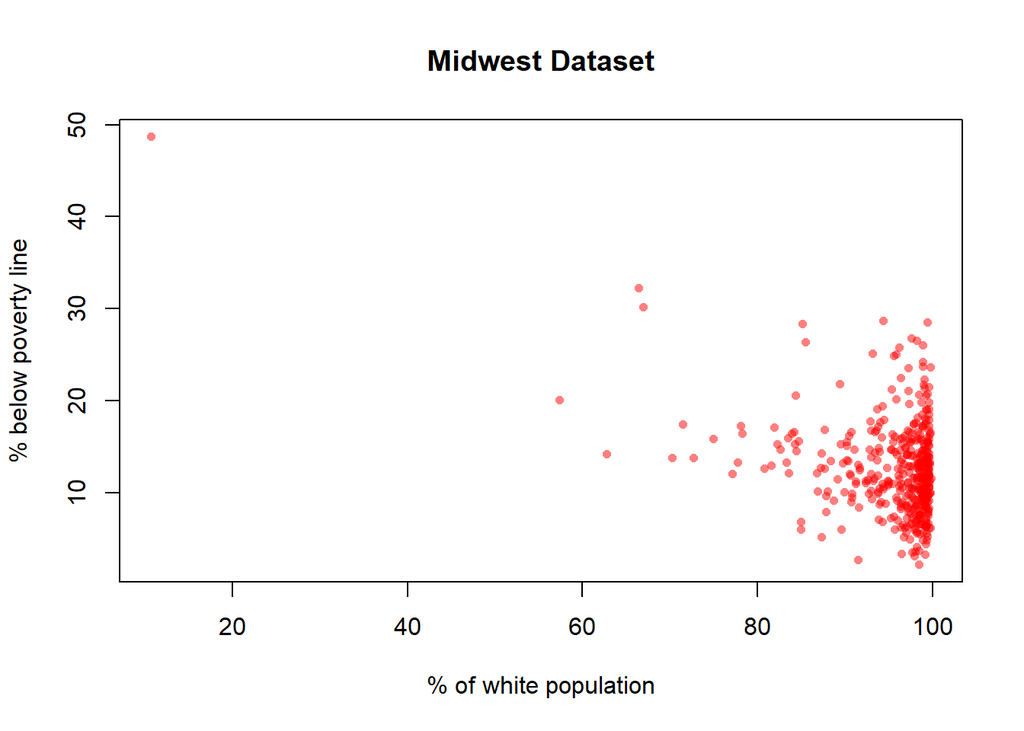

```r
plot(x, y, col = rgb(1, 0, 0, .5), pch = 16, cex = .75,
     main = "Midwest Dataset",
     xlab = "% of white population", ylab = "% below poverty line")
```

## Regresi Linear OLS

OLS (Ordinary Least Squares) atau MKT (Metode Kuadrat Terkecil) adalah metode regresi parametrik yang paling umum digunakan dalam statistika untuk mencari besaran hubungan linear antar peubah. Berikut adalah koefisien persamaan yang dihasilkan oleh regresi OLS. Di bawahnya adalah grafik yang menggambarkan persamaan tersebut.

```r
linReg <- lm(y ~ x)
coef(linReg)
```

```
## (Intercept)           x
##  38.6604624  -0.2736541
```

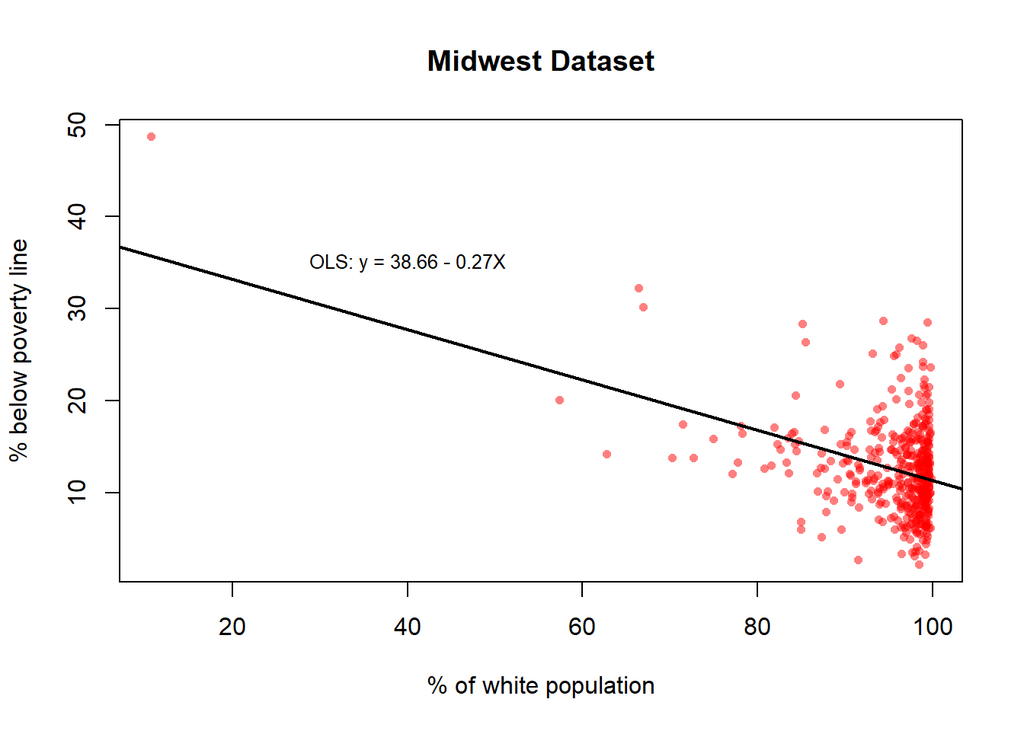

```r
plot(x, y, col = rgb(1, 0, 0, .5), pch = 16, cex = .75,
     main = "Midwest Dataset",
     xlab = "% of white population", ylab = "% below poverty line")
abline(linReg, lwd = 2)
text(40, 35, "OLS: y = 38.66 - 0.27X", cex = .8)
```

## Algoritma MML

**STEP 1**: Urutkan setiap data sesuai dengan peubah x-nya.

```r
y <- y[order(x)]  # y dirutkan (sesuai dengan urutan dari x)
x <- sort(x)  # x diurutkan

head(cbind(x, y))  # sehingga hasil akhir tetap berpasangan
```

```
##             x        y
## [1,] 10.69409 48.69110
## [2,] 57.39520 20.06530
## [3,] 62.77972 14.19830
## [4,] 66.38434 32.24428
## [5,] 66.88821 30.18411
## [6,] 70.27065 13.80515
```

**STEP 2**: Data akan dibagi menjadi 3 kelompok, maka carilah panjang yang sesuai untuk tiap kelompok

```r
n <- round(length(x)/3)
group1 <- 1:n
group2 <- (n + 1):(length(x) - n)
group3 <- (length(x) - n + 1):length(x)
```

```
##        min max length
## All      1 437    437
## Group1   1 146    146
## Group2 147 291    145
## Group3 292 437    146
```

**STEP 3**: Carilah median di setiap x & y per kelompok.

```r
x1 <- median(x[group1])
y1 <- median(y[group1])

x2 <- median(x[group2])
y2 <- median(y[group2])

x3 <- median(x[group3])
y3 <- median(y[group3])
```

```
##                x        y
## Group 1 92.79061 13.13309
## Group 2 98.03274 11.10143
## Group 3 99.27902 11.51767
```

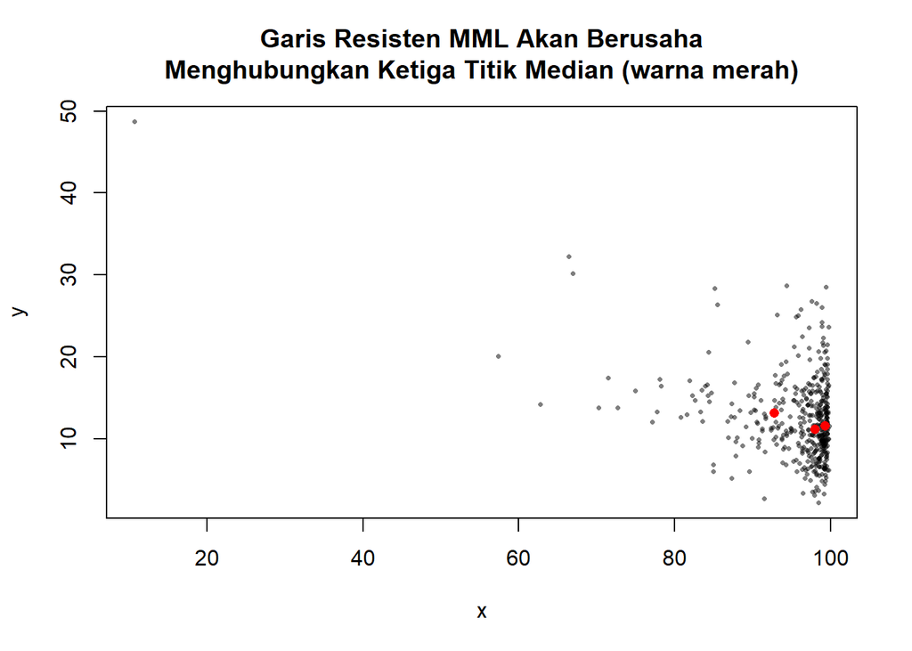

```r
plot(x, y, col = rgb(0, 0, 0, .5), pch = 16, cex = .5,
     main = "Garis Resisten MML Akan Berusaha
Menghubungkan Ketiga Titik Median (warna merah)")
points(c(x1, x2, x3), c(y1, y2, y3), col = "red", pch = 16)
```

**STEP 4**: Carilah rataan untuk setiap median-median x dan y.

```r
xbar <- mean(c(x1, x2, x3))
ybar <- mean(c(y1, y2, y3))
```

**STEP 5**: Carilah intercept dan slope dari garis MML.

```r
b1 <- (y3 - y1)/(x3 - x1)
b0 <- ybar - b1*xbar
```

```
##     Intercept   Slope
## OLS   38.6605 -0.2737
## MML   35.9930 -0.2490
```

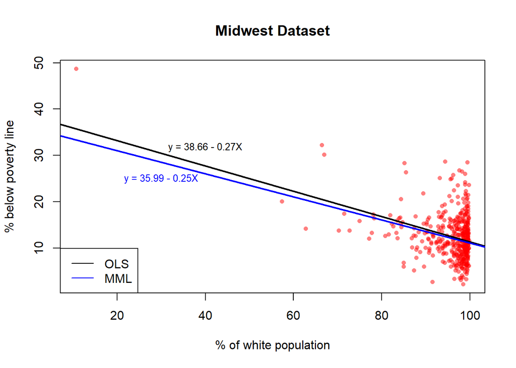

```r
plot(x, y, col = rgb(1, 0, 0, .5), pch = 16, cex = .75,
     main = "Midwest Dataset",
     xlab = "% of white population", ylab = "% below poverty line")

abline(linReg, lwd = 2)  # visualisasi OLS
abline(b0, b1, col = "blue", lwd = 2)  # visualisasi MML
legend("bottomleft", legend = c("OLS", "MML"), col = c("black", "blue"),
       lty = 1)

text(40, 31.8, "y = 38.66 - 0.27X", cex = .8)
text(30, 25, "y = 35.99 - 0.25X", cex = .8, col = "blue")
```

## Visualisasi OLS dan MML Menggunakan GGPlot

geom_point() untuk scatter plot.  
geom_smooth() untuk OLS.  
geom_abline() untuk MML.  
scale_color_manual() untuk meanmpilkan legenda.  
theme_bw() untuk mengubah tema.

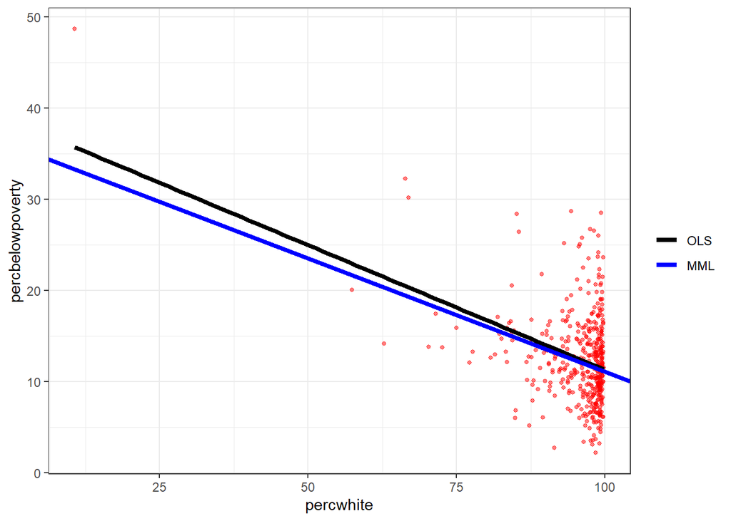

```r
library(ggplot2)

ggplot(data = df, mapping = aes(x = percwhite, y = percbelowpoverty)) +
    geom_point(colour = "red", alpha = .5, size = 1) +
    geom_smooth(method = "lm", formula = y ~ x, mapping = aes(col = "black"),
                size = 1.5, se = F) +
    geom_abline(mapping = aes(intercept = b0, slope = b1, col = "blue"),
                size = 1.5, show.legend = F) +
    scale_colour_manual(name = "",
                        labels = c("OLS", "MML"),
                        values = c("black", "blue")) +
    theme_bw()
```